# Using features of dynamic networks to guide treatment selection and outcome prediction

- Show All Code
- Hide All Code
- View Source

Simulation Study Visualizations

Authors

Affiliations

Björn S. Siepe

University of Marburg

Matthias Kloft

University of Marburg

Fridtjof Petersen

University of Groningen

Yong Zhang

University of Groningen

Laura F. Bringmann

University of Groningen

Daniel W. Heck

University of Marburg

Published

May 15, 2026

# 1 Background

This document contains code to reproduce the visualizations of the simulation study in the manuscript. It also contains additional results not shown in the main manuscript.

# 2 Preparation

Load relevant packages:

```r
library(tidyverse)
library(SimDesign)
library(cowplot)
library(showtext)
library(sysfonts)
library(ggokabeito)
library(janitor)
library(ggh4x)
library(pander)
library(MetBrewer)
library(here)
library(lm.beta)

source(here::here("scripts", "00_functions.R"))
```

To separate original results from our first revision, we add the subscript “rev1” to all new results:

```r
revision <- "rev1"
use_rev <- TRUE
```

Load the simulation results:

```r
if(isTRUE(use_rev)){
  sim_results <- readRDS(here::here("output", "sim_results_rev1_fixed_sigma.rds"))
} else {
  sim_results <- readRDS(here::here("output", "sim_results.RDS"))
}


# Create a cut version of the simulation results without MCMC diagnostics
sim_res_cut <- sim_results |>
  select(-contains("rhat")) |>
  select(-contains("divtrans"))
```

# 3 Data-Generating Processes

These are the data generating matrices that we used for our fixed effects:

VAR matrix:
$$\begin{bmatrix}
0.41 & 0.105 & 0.105 & 0.105 & 0.105 & 0.105 \\
0.105 & 0.35 & 0.075 & 0 & 0.075 & 0.075 \\
0.105 & 0 & 0.35 & 0.075 & 0 & 0.075 \\
0.105 & 0.075 & 0.075 & 0.35 & 0 & 0.075 \\
0.105 & 0.075 & 0.075 & 0.075 & 0.35 & 0 \\
0.105 & 0.075 & 0.075 & 0.075 & 0.075 & 0.35
\end{bmatrix}
\quad\quad$$
Innovation covariance matrix:
$$\begin{bmatrix}
1 & 0.188 & 0.188 & 0.188 & 0.188 & 0.188 \\
0.188 & 1 & 0.15 & 0.15 & 0 & 0.15 \\
0.188 & 0.15 & 1 & 0.15 & 0.15 & 0.15 \\
0.188 & 0.15 & 0.15 & 1 & 0.15 & 0.15 \\
0.188 & 0 & 0.15 & 0.15 & 1 & 0 \\
0.188 & 0.15 & 0.15 & 0.15 & 0 & 1
\end{bmatrix}$$

# 4 Deviations from Preregistration

We had multiple minor deviations from our preregistration, which mostly occurred due to errors on our side. We do not think that any of these decreases the informativeness of our study.

Also, after running the simulation study, we realized that our Stan code had an error in one line, where we standardized `reg_slope_density_z[9]` with `reg_slope_density[8]`. We corrected this error, and did not use this output anyway.

## 4.1 Overview Table

| Deviation | Explanation |
| --- | --- |
| Updated BmlVAR formula to fix subscripts and notation | The preregistered model formula omitted some necessary subscripts and used inconsistent distributional notation. These were corrected for clarity and correctness in the final version. |
| Renamed centrality predictor from `d` to `c` | The label `c` was chosen for clarity. |
| Incorrect prior notation for second step regression residual variance | We accidentally noted a t-prior on $log(sigma)$, but a half-t prior on $\sigma$ was used in both steps for consistency across models and had already been implemented in the code. We fixed the notation… |
| Omitted sum over individuals in centrality selection accuracy formula | The preregistered formula did not include a summation over individuals, which is necessary for the proportion. |
| 200 instead of 100 simulation repetitions | As we explained in the manuscript, we accidentally calculated that we needed 200 instead of the actual 100 simulation repetitions to achieve the desired worst-case MCSE. We kept the 200 repetitions as… |
| Added heterogeneous most central node condition | The preregistration specified only the homogeneous condition, in which the first node was constrained to be the most central node for all individuals. A coding error revealed that our initial implemen… |
| Added completely new simulation settings in the second revision | A reviewer suggested to add additional simulation conditions, which are included in `09_additional_simulations_viz.qmd` |

# 5 Data Wrangling

Prepare dataframe for visualization by giving proper names, removing unnecessary columns, and pivoting longer:

```r
sr_edit <- sim_res_cut |>
  mutate(
    dgp = factor(n_tp, levels = c(60, 120)),
    n_id = factor(n_id, levels = c(75, 200))
    ) |>
  # remove "reg_" from all column names
  rename_with(~str_remove(., "reg_")) |>
  # remove everything before a "." in the column names
  rename_with(~str_remove(., ".*\\.")) |>
  dplyr::select(-c("REPLICATIONS", "SIM_TIME", "SEED", "COMPLETED", "WARNINGS")) |>
  dplyr::select(-c("heterogeneity")) |>
  # pivot longer except conditions cols
  pivot_longer(cols = -c("dgp", "n_tp", "n_id"),
               names_to = "measure",
               values_to = "value") |>
  dplyr::mutate(measure = str_replace(measure, "power_reg", "powerreg"),
         measure = str_replace(measure, "powertwoside_reg", "powertwosidereg"),
         measure = str_replace(measure, "poweroneside_reg", "poweronesidereg"),
         measure = str_replace(measure, "rmse_reg", "rmsereg"),
         measure = str_replace(measure, "bias_reg", "biasreg"),
         measure = str_replace(measure, "mse_reg", "msereg")) |>
  dplyr::filter(!measure %in% c("strength_sd", "outstrength_sd", "instrength_sd")) |>
  separate_wider_delim(measure,
                       delim = "_",
                       names = c("pm", "outcome", "method", "summary")) |>
 dplyr::mutate(method = case_when(
    method == "gvar" ~ "GVAR",
    method == "gimme" ~ "GIMME",
    method == "mlvar" ~ "mlVAR",
    method == "bmlvar" ~ "BmlVAR"
  )) |>
  # treat method as factor and order
  dplyr::mutate(method = factor(method, levels = c("GVAR", "GIMME", "mlVAR", "BmlVAR"))) |>
  dplyr::mutate(outcome = case_when(
    outcome == "beta" ~ "Temporal",
    outcome == "pcor" ~ "Contemporaneous",
    .default = outcome
  )) |>
  dplyr::group_by(dgp, n_tp, n_id, pm, outcome, method) |>
  pivot_wider(names_from = summary, values_from = value) |>
  ungroup()
```

Prepare different colors and settings for visualization:

```r
meth_colors <- set_names(MetBrewer::met.brewer("Johnson")[c(1,2,4,5)],
                         c("GVAR", "mlVAR", "GIMME", "BmlVAR"))
```

# 6 Check Warnings and Errors

## 6.1 Errors

Check if any errors that led to non-convergence occurred:

```r
# load results before resummarization, which contain potential error messages
# for the first revision data, this is irrelevant
if(isTRUE(use_rev)){
  sim_full_pre_resum <- readRDS(here("output", "sim_results_rev1_fixed_sigma.rds"))
} else {
  sim_full_pre_resum <- readRDS(here("output", "sim_full.rds"))
}

sim_errors <- SimExtract(sim_full_pre_resum, "errors")
```

There were 0 error messages.

## 6.2 Warnings

We extract all warnings and rename them properly:

```r
sim_warnings <- SimExtract(sim_full_pre_resum, what = "warnings")

if(isTRUE(use_rev)){
  sim_warnings |>
  select(!c(heterogeneity, strength_sd, outstrength_sd, instrength_sd)) |>
  rename(
    "Deprecated dplyr function" = "WARNING:  c(\"Warning in NULL : `funs()` was deprecated in dplyr 0.8.0.\", \"Warning in NULL : Please use a list of either functions or lambdas: \\n\\n  # Simple nam",
    "Bulk ESS low" = "WARNING:  Warning in NULL : Bulk Effective Samples Size (ESS) is too low, indicating posterior means and medians may be unreliable.\nRunning the chains for more i",
    "Potential Stan sampling problems" = "WARNING:  Warning in NULL : Examine the pairs() plot to diagnose sampling problems\n",
    "Tail ESS low" = "WARNING:  Warning in NULL : Tail Effective Samples Size (ESS) is too low, indicating posterior variances and tail quantiles may be unreliable.\nRunning the chains",
    "NA R-hat" = "WARNING:  Warning in NULL : The largest R-hat is NA, indicating chains have not mixed.\nRunning the chains for more iterations may help. See\nhttps://mc-stan.org/mi",
    "Divergent transition" = "WARNING:  Warning in NULL : There were 1 divergent transitions after warmup. See\nhttps://mc-stan.org/misc/warnings.html#divergent-transitions-after-warmup\nto find",
    "Exceeded maximum treedepth" = "WARNING:  Warning in NULL : There were 491 transitions after warmup that exceeded the maximum treedepth. Increase max_treedepth above 10. See\nhttps://mc-stan.org",
    "Rothman algorithm warning" = "WARNING:  Warning in Rothmana(data_l, data_c, lambdas$beta[i], lambdas$kappa[i], regularize_mat_beta = regularize_mat_beta,     regularize_mat_kappa = regulariz",
    "Variable naming warning" = "WARNING:  Warning in validityMethod(object) : The following variables have undefined values:  reg_intercept_z[1],The following variables have undefined values: "
  ) |>
  knitr::kable()
} else {
  sim_warnings |>
  select(!c(heterogeneity, strength_sd, outstrength_sd, instrength_sd)) |>
  rename("Deprecated dplyr function" = "WARNING:  c(\"Warning in NULL : `funs()` was deprecated in dplyr 0.8.0.\", \"Warning in NULL : Please use a list of either functions or lambdas: \\n\\n  # Simple nam",
         "Bulk ESSlow" = "WARNING:  Warning in NULL : Bulk Effective Samples Size (ESS) is too low, indicating posterior means and medians may be unreliable.\nRunning the chains for more i",
         "Potential Stan sampling problems" = "WARNING:  Warning in NULL : Examine the pairs() plot to diagnose sampling problems\n",
         "Tail ESS low" = "WARNING:  Warning in NULL : Tail Effective Samples Size (ESS) is too low, indicating posterior variances and tail quantiles may be unreliable.\nRunning the chains",
         "NA R-hat" = "WARNING:  Warning in NULL : The largest R-hat is NA, indicating chains have not mixed.\nRunning the chains for more iterations may help. See\nhttps://mc-stan.org/mi",
         "Divergent transition" = "WARNING:  Warning in NULL : There were 1 divergent transitions after warmup. See\nhttps://mc-stan.org/misc/warnings.html#divergent-transitions-after-warmup\nto find",
         "Exceeded maximum treedepth" = "WARNING:  Warning in NULL : There were 497 transitions after warmup that exceeded the maximum treedepth. Increase max_treedepth above 10. See\nhttps://mc-stan.org",
         "Rothman algorithm warning" = "WARNING:  Warning in Rothmana(data_l, data_c, lambdas$beta[i], lambdas$kappa[i], regularize_mat_beta = regularize_mat_beta,     regularize_mat_kappa = regulariz",
         "Variable naming warning" = "WARNING:  Warning in validityMethod(object) : The following variables have undefined values:  reg_intercept_z[1],The following variables have undefined values: ") |>
  knitr::kable()
}
```

| dgp | n_id | n_tp | Deprecated dplyr function | Bulk ESS low | Potential Stan sampling problems | Tail ESS low | NA R-hat | Divergent transition | Exceeded maximum treedepth | Rothman algorithm warning | Variable naming warning |
| --- | --- | --- | --- | --- | --- | --- | --- | --- | --- | --- | --- |
| sparse | 75 | 60 | 60 | 199 | 98 | 200 | 24 | 98 | 4 | 5209 | 27 |
| sparse | 200 | 60 | 0 | 199 | 0 | 148 | 7 | 0 | 0 | 13718 | 33 |
| sparse | 75 | 120 | 60 | 199 | 98 | 200 | 24 | 98 | 4 | 5209 | 27 |
| sparse | 200 | 120 | 0 | 199 | 0 | 148 | 7 | 0 | 0 | 13718 | 33 |

Unfortunately, we removed warnings from `mlVAR` during our simulation. However, in our additional simulations in `06_additional_mlvar_simulation.qmd`, we noticed that warning messages from mlVAR were only related to the renaming of certain variables, so we assume that we did not miss any substantial warnings.

The warnings from the Rothman algorithm in `graphicalVAR` are substantial in quantity, but they also occured regulary in simulations where the point estimates were relatively accurate. We therefore did not use them to exclude any interations.

# 7 Point Estimates

Plot point estimate recovery as mean squared error (MSE) which is helpful to understand the overall performance of the different methods.

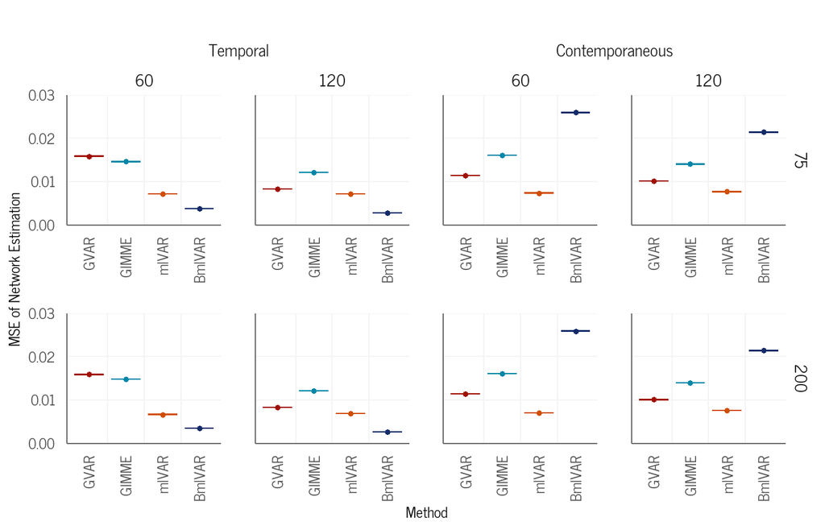

```r
plot_mse <- sr_edit |>
  mutate(mcse = ifelse(is.na(mcse), 0, mcse)) |>
  mutate(outcome = factor(outcome, levels = c("Temporal", "Contemporaneous"))) |>
  filter(pm == "mse") |>
  ggplot(aes(x = method,
             y = mean,
             colour = method
             )) +
  # add vertical line between methods
  geom_vline(colour = "#F3F4F5", xintercept = seq(1.5, 4, 1))+
  geom_errorbar(aes(ymin = mean - 1*mcse,
                            ymax = mean + 1*mcse),
                        width = .8,
                 position = position_dodge(0.7),
                 show.legend = FALSE)+
  geom_point(position = position_dodge(0.7),
             size = 1.2) +
  ggh4x::facet_nested(n_id ~ outcome + n_tp,
                      axes = "all",
                      remove_labels = "y") +
  scale_x_discrete(guide = guide_axis(angle = 90))+
  scale_y_continuous(expand = c(0, 0), limits = c(0,0.03)) +
  scale_color_manual(values = meth_colors) +
  theme_centrality()+
  theme(legend.position = "none",
        text = element_text(size = 22))+
  labs(title = "",
       x = "Method",
       colour = "Method",
       y = "MSE of Network Estimation")

plot_mse
```

Plot Bias:

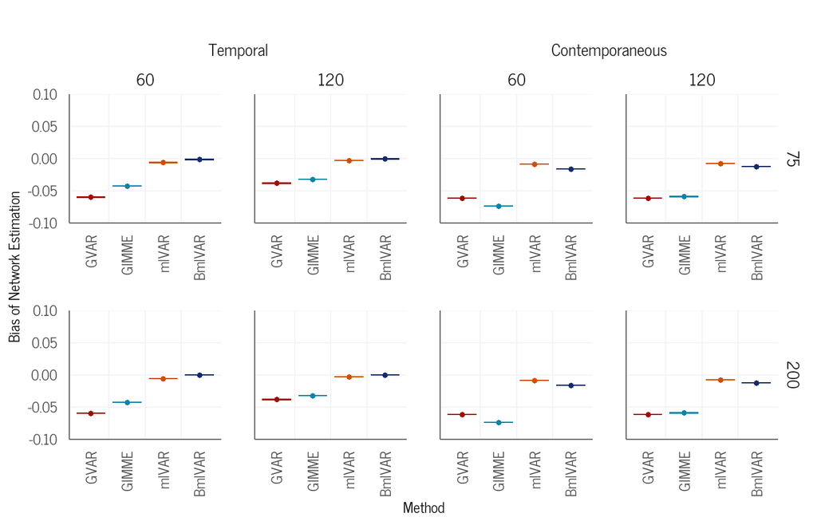

```r
plot_bias <- sr_edit |>
  mutate(mcse = ifelse(is.na(mcse), 0, mcse)) |>
  mutate(outcome = factor(outcome, levels = c("Temporal", "Contemporaneous"))) |>
  filter(pm == "bias") |>
  ggplot(aes(x = method,
             y = mean,
             colour = method
             )) +
  # add vertical line between methods
  geom_vline(colour = "#F3F4F5", xintercept = seq(1.5, 4, 1))+
  geom_errorbar(aes(ymin = mean - 1*mcse,
                            ymax = mean + 1*mcse),
                        width = .8,
                 position = position_dodge(0.7),
                 show.legend = FALSE)+
  geom_point(position = position_dodge(0.7),
             size = 1.2) +
  ggh4x::facet_nested(n_id ~ outcome + n_tp,
                      axes = "all",
                      remove_labels = "y") +
  scale_x_discrete(guide = guide_axis(angle = 90))+
  scale_y_continuous(expand = c(0, 0), limits = c(-0.1,0.1)) +
  scale_color_manual(values = meth_colors) +
  theme_centrality() +
  theme(legend.position = "none",
        text = element_text(size = 22))+
  labs(title = "",
       x = "Method",
       colour = "Method",
       y = "Bias of Network Estimation")

plot_bias
```

# 8 Centrality

## 8.1 Proportion of Correctly Identified Nodes with the Highest Centrality

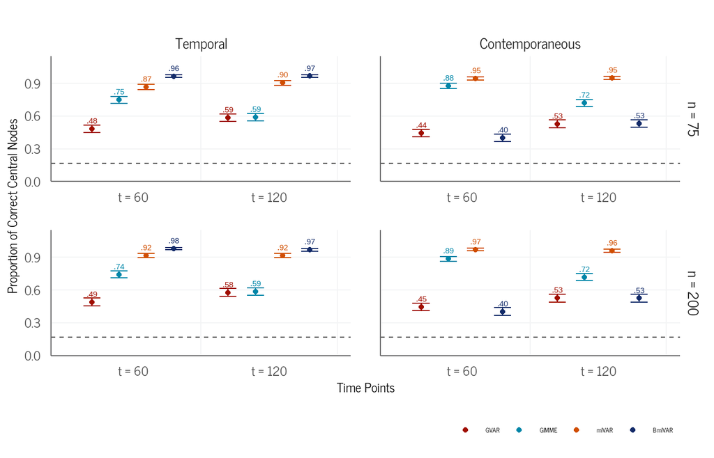

```r
plot_mostcentral <- sr_edit |>
  # if mcse is missing, set to 0
  mutate(mcse = ifelse(is.na(mcse), 0, mcse)) |>
  mutate(outcome = factor(outcome, levels = c("Temporal", "Contemporaneous"))) |>
  filter(pm == "mostcent") |>
  mutate(n_tp = paste0("t = ", n_tp)) |>
  mutate(n_tp = factor(n_tp, levels = c("t = 60", "t = 120"))) |>
  mutate(n_id = paste0("n = ", n_id)) |>
  mutate(n_id = factor(n_id, levels = c("n = 75", "n = 200"))) |>
  ggplot(aes(x = as.factor(n_tp),
             y = mean,
             group = method,
             colour = method
             )) +
  # horizontal line at chance level of 1/6
  geom_hline(yintercept = 1/6,
             linetype = 2,
             alpha = .7)+
  # add vertical line between methods
  geom_vline(colour = "#F3F4F5", xintercept = seq(1.5, 3, 1))+
  geom_errorbar(aes(ymin = mean - 1*mcse,
                            ymax = mean + 1*mcse),
                        width = .5,
                 position = position_dodge(0.8),
                 show.legend = FALSE)+
  geom_point(position = position_dodge(0.8),
             size = 1.4) +
  # add mean as text above errorbar
    geom_text(aes(label = sub("^(-?)0.", "\\1.",sprintf("%.2f", mean))),
              position = position_dodge(0.8),
              vjust = -1.0,
              size = 4,
              show.legend = FALSE) +
  ggh4x::facet_nested(n_id ~ outcome,
                      axes = "all",
                      remove_labels = "y") +
  # scale_x_discrete(guide = guide_axis(angle = 90))+
  scale_y_continuous(expand = c(0, 0), limits = c(0,1.15)) +
  scale_color_manual(values = meth_colors) +
  theme_centrality() +
  theme(legend.position = "bottom",
        title = element_text(size = 27)
        )+
  labs(title = "",
       x = "Time Points",
       colour = "",
       y = "Proportion of Correct Central Nodes")

ggsave_rev("plot_mostcentral.pdf", plot_mostcentral, height = 6 * 1.1, width = 9 * 1.1,
       path = here::here("figures/"), device = "pdf")

plot_mostcentral
```

Create the same plot for a presentation with slightly different visuals:

```r
plot_mostcentral_presentation <- sr_edit |>
  # if mcse is missing, set to 0
  mutate(mcse = ifelse(is.na(mcse), 0, mcse)) |>
  mutate(outcome = factor(outcome, levels = c("Temporal", "Contemporaneous"))) |>
  filter(pm == "mostcent") |>
  mutate(n_tp = paste0("t = ", n_tp)) |>
  mutate(n_tp = factor(n_tp, levels = c("t = 60", "t = 120"))) |>
  mutate(n_id = paste0("n = ", n_id)) |>
  mutate(n_id = factor(n_id, levels = c("n = 75", "n = 200"))) |>
  ggplot(aes(x = as.factor(n_tp),
             y = mean,
             group = method,
             colour = method
             )) +
  # horizontal line at chance level of 1/6
  geom_hline(yintercept = 1/6,
             linetype = 2,
             alpha = .7)+
  # add vertical line between methods
  geom_vline(colour = "#F3F4F5", xintercept = seq(1.5, 3, 1))+
  geom_errorbar(aes(ymin = mean - 1*mcse,
                            ymax = mean + 1*mcse),
                        width = .5,
                 position = position_dodge(0.8),
                 show.legend = FALSE)+
  geom_point(position = position_dodge(0.8),
             size = 1.4) +
  # add mean as text above errorbar
    geom_text(aes(label = sub("^(-?)0.", "\\1.",sprintf("%.2f", mean))),
              position = position_dodge(0.8),
              vjust = -1.0,
              size = 4,
              show.legend = FALSE) +
  ggh4x::facet_nested(n_id ~ outcome,
                      axes = "all",
                      remove_labels = "y") +
  # scale_x_discrete(guide = guide_axis(angle = 90))+
  scale_y_continuous(expand = c(0, 0), limits = c(0,1.15)) +
  scale_color_manual(values = meth_colors) +
  theme_centrality() +
  theme(legend.position = "bottom",
          axis.text.x = element_text(size = 22),
          axis.text.y = element_text(size = 22),
          axis.title.x = element_text(size = 24),
          # increase all legend element size
          legend.text = element_text(size = 24),
          legend.title = element_text(size = 24),
          legend.key.size = unit(1.6, "lines"),
          strip.text = ggplot2::element_text(size = 24),
          strip.text.x.top = ggplot2::element_text(size = 24),
          plot.title = ggplot2::element_text(size = 29))+
  # Remove title for paper, keep title for poster/presentations
  labs(title = "All models struggle to identify the most central node",
       x = "Time Points",
       colour = "",
       y = "Proportion of Correct Central Nodes")

ggsave_rev("plot_mostcentral_presentation.pdf", plot_mostcentral_presentation, height = 6 * 1.2, width = 9 * 1.2,
       path = here::here("figures/"), device = "pdf")

plot_mostcentral_presentation
```

### 8.1.1 Combining homogeneous and heterogeneous conditions

For the manuscript, we can also combine the homogeneous and heterogeneous conditions into one plot. To do so, we first need to load both results dataframes:

```r
# load heterogeneous simulations
sim_results_het <- readRDS(here::here("output", "sim_results_rev1_heterogeneous.rds"))

# cut irrelevant columns
sim_res_het_cut <- sim_results_het |>
  select(-contains("rhat")) |>
  select(-contains("divtrans"))

sr_edit_het <- sim_res_het_cut |>
  mutate(
    dgp = factor(n_tp, levels = c(60, 120)),
    n_id = factor(n_id, levels = c(75, 200))
    ) |>
  # remove "reg_" from all column names
  rename_with(~str_remove(., "reg_")) |>
  # remove everything before a "." in the column names
  rename_with(~str_remove(., ".*\\.")) |>
  dplyr::select(-c("REPLICATIONS", "SIM_TIME", "SEED", "COMPLETED", "WARNINGS")) |>
  dplyr::select(-c("heterogeneity")) |>
  # pivot longer except conditions cols
  pivot_longer(cols = -c("dgp", "n_tp", "n_id"),
               names_to = "measure",
               values_to = "value") |>
  mutate(measure = str_replace(measure, "power_reg", "powerreg"),
         measure = str_replace(measure, "powertwoside_reg", "powertwosidereg"),
         measure = str_replace(measure, "poweroneside_reg", "poweronesidereg"),
         measure = str_replace(measure, "rmse_reg", "rmsereg"),
         measure = str_replace(measure, "bias_reg", "biasreg"),
         measure = str_replace(measure, "mse_reg", "msereg")) |>
  filter(!measure %in% c("strength_sd", "outstrength_sd", "instrength_sd")) |>
  separate_wider_delim(measure,
                       delim = "_",
                       names = c("pm", "outcome", "method", "summary")) |>
  mutate(method = case_when(
    method == "gvar" ~ "GVAR",
    method == "gimme" ~ "GIMME",
    method == "mlvar" ~ "mlVAR",
    method == "bmlvar" ~ "BmlVAR"
  )) |>
  # treat method as factor and order
  mutate(method = factor(method, levels = c("GVAR", "GIMME", "mlVAR", "BmlVAR"))) |>
  mutate(outcome = case_when(
    outcome == "beta" ~ "Temporal",
    outcome == "pcor" ~ "Contemporaneous",
    .default = outcome
  )) |>
  group_by(dgp, n_tp, n_id, pm, outcome, method) |>
  pivot_wider(names_from = summary, values_from = value) |>
  ungroup()


# Create heterogeneous plot
plot_mostcentral_het <- sr_edit_het |>
  # if mcse is missing, set to 0
  mutate(mcse = ifelse(is.na(mcse), 0, mcse)) |>
  mutate(outcome = factor(outcome, levels = c("Temporal", "Contemporaneous"))) |>
  filter(pm == "mostcent") |>
  mutate(n_tp = paste0("t = ", n_tp)) |>
  mutate(n_tp = factor(n_tp, levels = c("t = 60", "t = 120"))) |>
  mutate(n_id = paste0("n = ", n_id)) |>
  mutate(n_id = factor(n_id, levels = c("n = 75", "n = 200"))) |>
  ggplot(aes(x = as.factor(n_tp),
             y = mean,
             group = method,
             colour = method
             )) +
  # horizontal line at chance level of 1/6
  geom_hline(yintercept = 1/6,
             linetype = 2,
             alpha = .7)+
  # add vertical line between methods
  geom_vline(colour = "#F3F4F5", xintercept = seq(1.5, 3, 1))+
  geom_errorbar(aes(ymin = mean - 1*mcse,
                            ymax = mean + 1*mcse),
                        width = .5,
                 position = position_dodge(0.8),
                 show.legend = FALSE)+
  geom_point(position = position_dodge(0.8),
             size = 1.4) +
  # add mean as text above errorbar
  geom_text(aes(label = sub("^(-?)0.", "\\1.",sprintf("%.2f", mean))),
              position = position_dodge(0.8),
              vjust = -1.0,
              size = 4,
              show.legend = FALSE) +
  ggh4x::facet_nested(n_id ~ outcome,
                      axes = "all",
                      remove_labels = "y") +
  # scale_x_discrete(guide = guide_axis(angle = 90))+
  scale_y_continuous(expand = c(0, 0), limits = c(0,1.15)) +
  scale_color_manual(values = meth_colors) +
  theme_centrality() +
  theme(legend.position = "bottom",
        title = element_text(size = 27)
        )+
  labs(title = "",
       x = "Time Points",
       colour = "",
       y = "Proportion of Correct Central Nodes")

# combine both plots into one
# obtain common legend
plot_legend_source <- plot_mostcentral +
  theme(legend.position = "bottom",
        text = element_text(size = 20),
        # increase all legend element size
        legend.text = element_text(size = 18),
        legend.title = element_text(size = 18),
        legend.key.size = unit(1.6, "lines"))

# extract the legend
legend <- cowplot::get_plot_component(plot_legend_source, 'guide-box-bottom', return_all = TRUE)

# combine the two plots (no labels)
plot_combined <- cowplot::plot_grid(plot_mostcentral + theme(legend.position = "none"),
                                    plot_mostcentral_het + theme(legend.position = "none"),
                                    ncol = 1,
                                    nrow = 2,
                                    labels = c("Homogeneous", "Heterogeneous"),
                                    label_fontfamily  = "news",
                                    label_size = 20)

# add legend below
combined_mostcentral_plot <- cowplot::plot_grid(
  plot_combined,
  legend,
  ncol = 1,
  nrow = 2,
  rel_heights = c(1, 0.1)
)

ggsave_rev("plot_mostcentral_combined.pdf", combined_mostcentral_plot, height = 11 * 1.2, width = 9 * 1.2,
       path = here::here("figures/"), device = "pdf")
```

## 8.2 Plot rank correlation of centrality measures

We were interested in the performance of centrality estimation, which we assessed with regard to rank-order performance. As we expected centrality estimates to be biased downwards in some methods due to sparsity assumptions, we computed the rank-order consistency of individual centrality estimates. To do so, we computed the point estimate of network centrality $\hat{c}$ per individual in a data set, which ignored estimation uncertainty. We then estimated the Spearman rank correlation $\hat{\rho}_{i}$ in repetition $i$ of these estimates with the true network centrality $c$ and calculated its average across repetitions as:
$$\begin{align*}
\widehat{\rho} = \frac{\sum_{i=1}^{n_{\text{sim}}} \hat{\rho}_i}{n_{\text{sim}}}
\end{align*}$$
We calculated the MCSE of this correlation via bootstrapping.

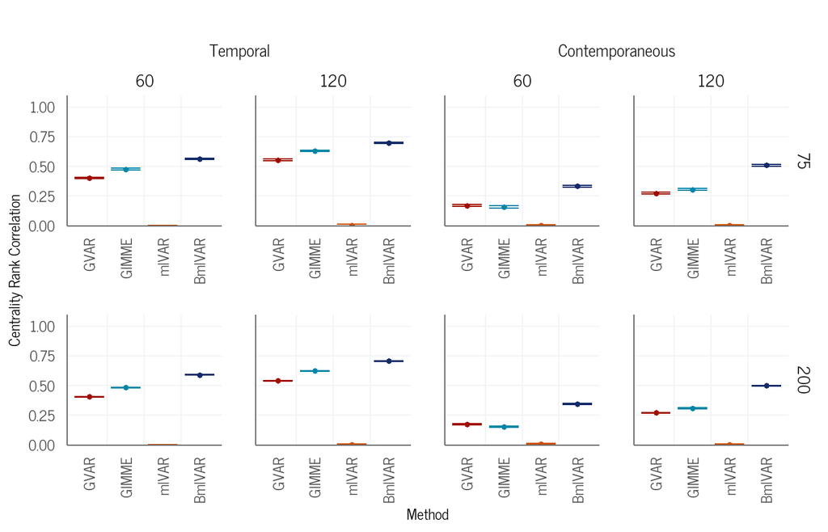

```r
plot_rankcor <- sr_edit |>
  # if mcse is missing, set to 0
  mutate(mcse = ifelse(is.na(mcse), 0, mcse)) |>
  # uselessly used temp and cont instead of beta and pcor here
  mutate(outcome = case_when(
    outcome == "temp" ~ "Temporal",
    outcome == "cont" ~ "Contemporaneous"
  )) |>
  mutate(outcome = factor(outcome, levels = c("Temporal", "Contemporaneous"))) |>
  filter(pm == "rankcor") |>
  ggplot(aes(x = method,
             y = mean,
             colour = method
             )) +
  # add vertical line between methods
  geom_vline(colour = "#F3F4F5", xintercept = seq(1.5, 4, 1))+
  geom_errorbar(aes(ymin = mean - 1*mcse,
                            ymax = mean + 1*mcse),
                        width = .8,
                 position = position_dodge(0.7),
                 show.legend = FALSE)+
  geom_point(position = position_dodge(0.7),
             size = 1.2) +
  ggh4x::facet_nested(n_id ~ outcome + n_tp,
                      axes = "all",
                      remove_labels = "y") +
  scale_x_discrete(guide = guide_axis(angle = 90))+
  scale_y_continuous(expand = c(0, 0), limits = c(0,1.1)) +
  scale_color_manual(values = meth_colors) +
  theme_centrality() +
  theme(legend.position = "none",
        text = element_text(size = 22))+
  labs(title = "",
       x = "Method",
       colour = "Method",
       y = "Centrality Rank Correlation")


ggsave_rev("plot_rankcor.pdf", plot_rankcor, height = 12, width = 16,
       path = here::here("figures/"), device = "pdf")

plot_rankcor
```

## 8.3 Bias and MSE of Centrality

Based on a reviewer comment, we also added the bias and MSE of the centrality of the first node to this supplement. We first need to compute it, as we didn’t compute it in our initial simulation. Note that the computation code is commented out so as not to clash with our make file, which forces execution. The results are re-loaded below.

```r
# node1_cent_cond14 <- resummarise_node1_centrality(
#  dir = here::here("output", "rev1_fixed_sigma",
#                   "sim_full_rev1_cond14_fixed_sigma.rds-results_pc04798"),
#  output_file = here::here("output", "node1_centrality_rev1_cond14_fixed_sigma.rds")
# )

# node1_cent_cond23 <- resummarise_node1_centrality(
#  dir = here::here("output", "rev1_fixed_sigma",
#                    "sim_full_rev1_cond23_fixed_sigma.rds-results_pc04669"),
#  output_file = here::here("output", "node1_centrality_rev1_cond23_fixed_sigma.rds")
# )

# node1_cent <- dplyr::bind_rows(node1_cent_cond14, node1_cent_cond23)

# saveRDS(node1_cent,
#        here::here("output", "node1_centrality_rev1_fixed_sigma.rds"))

# node1_cent
```

After computing it once, we can reload it and plot the results:

```r
node1_cent <- readRDS(here::here("output", "node1_centrality_rev1_fixed_sigma.rds"))

node1_cent_long <- node1_cent |>
  dplyr::mutate(
    n_tp = factor(n_tp, levels = c(60, 120)),
    n_id = factor(n_id, levels = c(75, 200))
    ) |>
  # remove "node1_" from all column names
  rename_with(~str_remove(., "node1")) |>
  dplyr::select(-c("heterogeneity")) |>
  # pivot longer except conditions cols
  pivot_longer(cols = -c("dgp", "n_tp", "n_id"),
               names_to = "measure",
               values_to = "value") |>
  dplyr::filter(!measure %in% c("strength_sd", "outstrength_sd", "instrength_sd")) |>
  separate_wider_delim(measure,
                       delim = "_",
                       names = c("pm", "outcome", "method", "summary")) |>
 dplyr::mutate(method = case_when(
    method == "gvar" ~ "GVAR",
    method == "gimme" ~ "GIMME",
    method == "mlvar" ~ "mlVAR",
    method == "bmlvar" ~ "BmlVAR"
  )) |>
  # treat method as factor and order
  dplyr::mutate(method = factor(method, levels = c("GVAR", "GIMME", "mlVAR", "BmlVAR"))) |>
  dplyr::mutate(outcome = case_when(
    outcome == "beta" ~ "Temporal",
    outcome == "pcor" ~ "Contemporaneous",
    .default = outcome
  )) |>
  dplyr::group_by(dgp, n_tp, n_id, pm, outcome, method) |>
  pivot_wider(names_from = summary, values_from = value) |>
  ungroup()
```

Plot MSE:

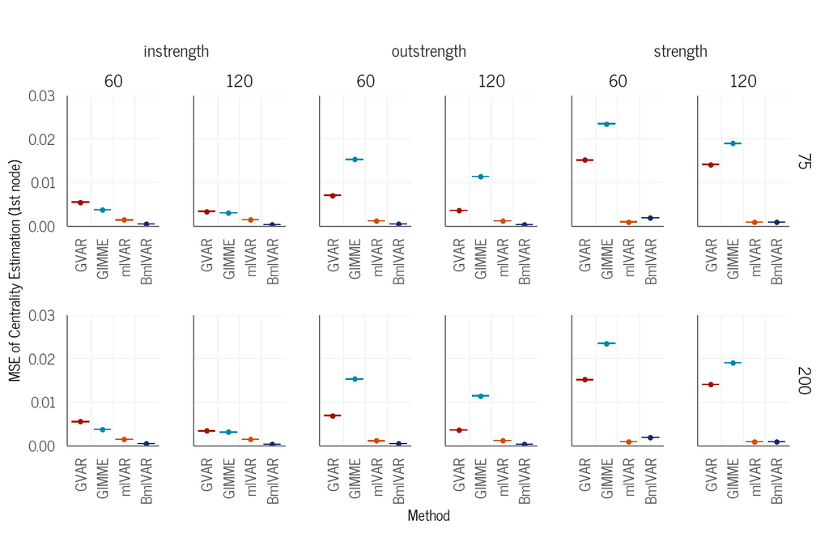

```r
plot_mse <- node1_cent_long |>
  mutate(mcse = ifelse(is.na(mcse), 0, mcse)) |>
  mutate(outcome = factor(outcome, levels = c("instrength", "outstrength", "strength"))) |>
  filter(pm == "mse") |>
  ggplot(aes(x = method,
             y = mean,
             colour = method
             )) +
  # add vertical line between methods
  geom_vline(colour = "#F3F4F5", xintercept = seq(1.5, 4, 1))+
  geom_errorbar(aes(ymin = mean - 1*mcse,
                            ymax = mean + 1*mcse),
                        width = .8,
                 position = position_dodge(0.7),
                 show.legend = FALSE)+
  geom_point(position = position_dodge(0.7),
             size = 1.2) +
  ggh4x::facet_nested(n_id ~ outcome + n_tp,
                      axes = "all",
                      remove_labels = "y") +
  scale_x_discrete(guide = guide_axis(angle = 90))+
  scale_y_continuous(expand = c(0, 0), limits = c(0,0.03)) +
  scale_color_manual(values = meth_colors) +
  theme_centrality()+
  theme(legend.position = "none",
        text = element_text(size = 22))+
  labs(title = "",
       x = "Method",
       colour = "Method",
       y = "MSE of Centrality Estimation (1st node)")

plot_mse
```

Plot Bias:

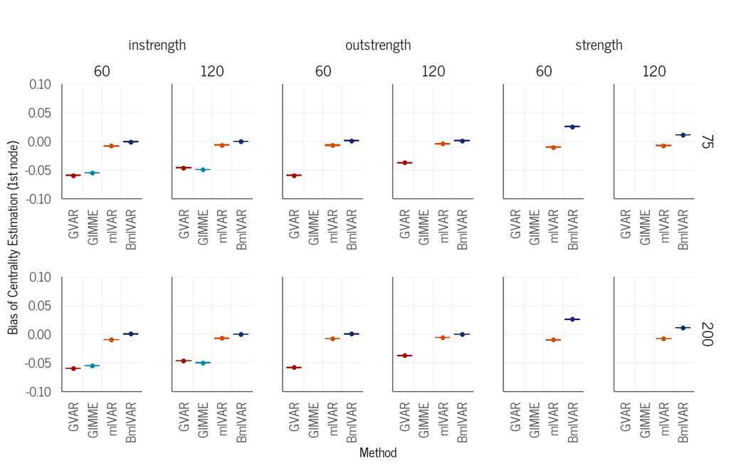

```r
plot_bias <- node1_cent_long |>
  mutate(mcse = ifelse(is.na(mcse), 0, mcse)) |>
  mutate(outcome = factor(outcome, levels = c("instrength", "outstrength", "strength"))) |>
  filter(pm == "bias") |>
  ggplot(aes(x = method,
             y = mean,
             colour = method
             )) +
  # add vertical line between methods
  geom_vline(colour = "#F3F4F5", xintercept = seq(1.5, 4, 1))+
  geom_errorbar(aes(ymin = mean - 1*mcse,
                            ymax = mean + 1*mcse),
                        width = .8,
                 position = position_dodge(0.7),
                 show.legend = FALSE)+
  geom_point(position = position_dodge(0.7),
             size = 1.2) +
  ggh4x::facet_nested(n_id ~ outcome + n_tp,
                      axes = "all",
                      remove_labels = "y") +
  scale_x_discrete(guide = guide_axis(angle = 90))+
  scale_y_continuous(expand = c(0, 0), limits = c(-0.1,0.1)) +
  scale_color_manual(values = meth_colors) +
  theme_centrality() +
  theme(legend.position = "none",
        text = element_text(size = 22))+
  labs(title = "",
       x = "Method",
       colour = "Method",
       y = "Bias of Centrality Estimation (1st node)")

plot_bias
```

# 9 Regression

## 9.1 Power of Regression

### 9.1.1 In- and Outstrength combined

Prep data

```r
# Split data set into three based on true effect
power_df <- sr_edit |>
  filter(!str_detect(pm, "poweroneside")) |>
  mutate(pm = str_replace(pm, "powertwoside", "power")) |>
  filter(str_detect(pm, "power")) |>
  mutate(outcome = case_when(
    # outcome == "tempdens" ~ "Temporal\nDensity",
    # outcome == "contdens" ~ "Contemporaneous\nDensity",
    outcome == "outstrength" ~ "Temporal\nOutstrength",
    outcome == "strength" ~ "Contemporaneous\nStrength",
    outcome == "instrength" ~ "Temporal\nInstrength"
  )) |>
  # For now, remove contemporaneous strength
  filter(outcome != "Contemporaneous\nStrength") |>
  mutate(n_id = paste0("n = ", n_id)) |>
  mutate(n_id = factor(n_id, levels = c("n = 75", "n = 200"))) |>
  mutate(n_tp = paste0("t = ", n_tp)) |>
  mutate(n_tp = factor(n_tp, levels = c("t = 60", "t = 120"))) |>
  # split pm into two columns, take last number into new column
  separate_wider_delim(pm, delim = "reg", names = c("pm", "true_effect"))

power_list <- split(power_df, power_df$true_effect)
```

Function to create the plots:

```r
# Function to create the plot for a given dataframe
power_plot <- function(df) {
  ggplot(df, aes(x = n_tp,
                 y = mean,
                 colour = method,
                 fill = method,
                 group = method)) +
    geom_errorbar(aes(ymin = mean - 1 * mcse,
                      ymax = mean + 1 * mcse),
                  width = 0.5,
                  position = position_dodge(0.7),
                  show.legend = FALSE) +
    # add vertical
    geom_vline(colour = "#F3F4F5", xintercept = seq(1.5, 4, 1))+
    geom_point(position = position_dodge(0.7),
               size = 1.4) +
    ggh4x::facet_nested(n_id ~ outcome,
                        axes = "all",
                        remove_labels = "y") +
    # scale_x_discrete(guide = guide_axis(angle = 90)) +
    scale_y_continuous(expand = c(0, 0), limits = c(-0.1, 1.1)) +
    scale_color_manual(values = meth_colors) +
    theme_centrality() +
    theme(legend.position = "none",
          strip.text.x.top = ggplot2::element_text(size = rel(0.85)),
          ggh4x.facet.nestline = element_line(colour = "#6d6d6e"),
          axis.text = element_text(size = 18)) +
    labs(title = "",
         x = "",
         colour = "",
         fill = "",
         group = "",
         y = "Detection Rate")
}
```

Create the plots and combine them with patchwork

```r
plot_power_list <- lapply(power_list, power_plot)

# add legend to the third plot
plot_3_legend <- plot_power_list[[3]] +
  theme(legend.position = "bottom",
        text = element_text(size = 25))

# extract legend
legend <- cowplot::get_plot_component(plot_3_legend, 'guide-box-bottom', return_all = TRUE)

# add legend to cowplot
plot_power_combined <- cowplot::plot_grid(plot_power_list[[1]],
                                          plot_power_list[[2]],
                                          plot_power_list[[3]],
                                          legend,
                                          ncol = 1,
                                          nrow = 4,
                                          rel_heights = c(1, 1, 1, 0.1),
                                          labels = c("True Effect: 0",
                                                     "True Effect: 0.2",
                                                     "True Effect: 0.4",
                                                     ""),
                                          label_fontfamily = "news",
                                          label_size = 18)




ggsave_rev("plot_power_combined.pdf", plot_power_combined, height = 16* 0.95, width = 16* 0.8,
       path = here::here("figures/"))
ggsave_rev("plot_power_combined.svg", plot_power_combined, height = 16* 0.95, width = 16* 0.8,
       path = here::here("scripts", "simulation_viz_figures"))
```

How large was the difference between instrength and outstrength?

```r
power_df |>
  pivot_wider(id_cols = c(dgp, n_id, n_tp, pm, true_effect, method),
              names_from = outcome,
              values_from = c(mean, mcse)) |>
  filter(true_effect != 0) |>
  janitor::clean_names() |>
  mutate(mean_diff = mean_temporal_instrength - mean_temporal_outstrength) |>
  summarize(mean_mean_diff = mean(mean_diff)) |>
  knitr::kable()
```

| mean_mean_diff |
| --- |
| 0.0873438 |

## 9.2 Power and Bias for Outstrength

This reproduces the simulation figure in the manuscript.

```r
power_bias_reg_combined_df <- sr_edit |>
  mutate(pm = str_replace(pm, "powertwoside", "power")) |>
  filter(!str_detect(pm, "poweroneside")) |>
  filter(str_detect(pm, "power") | str_detect(pm, "biasreg")) |>
    mutate(outcome = case_when(
    outcome == "outstrength" ~ "Temporal\nOutstrength",
    outcome == "strength" ~ "Contemporaneous\nStrength",
    outcome == "instrength" ~ "Temporal\nInstrength"
  )) |>
  filter(outcome == "Temporal\nOutstrength") |>
  mutate(n_id = paste0("n = ", n_id)) |>
  mutate(n_id = factor(n_id, levels = c("n = 75", "n = 200"))) |>
  mutate(n_tp = paste0("t = ", n_tp)) |>
  mutate(n_tp = factor(n_tp, levels = c("t = 60", "t = 120"))) |>
  # split pm into two columns, take last number into new column
  separate_wider_delim(pm, delim = "reg", names = c("pm", "true_effect")) |>
  mutate(method = factor(method, levels = c("GVAR", "GIMME", "mlVAR", "BmlVAR"))) |>
  mutate(true_effect = paste0("True Effect: .", true_effect)) |>
  mutate(pm = case_when(
    str_detect(pm, "power") ~ "Detection Rate",
    str_detect(pm, "bias") ~ "Bias"
  ))

plot_power_bias_outstrength <- power_bias_reg_combined_df |>
  ggplot(aes(x = n_tp,
             y = mean,
             colour = method,
             fill = method,
             group = method))+
  geom_errorbar(aes(ymin = mean - 1 * mcse,
                      ymax = mean + 1 * mcse),
                  width = 0.5,
                  position = position_dodge(0.8),
                  show.legend = FALSE) +
    # add vertical
    geom_vline(colour = "#F3F4F5", xintercept = seq(1.5, 4, 1))+
    geom_point(position = position_dodge(0.8),
               size = 1.4) +
    # add mean without leading zero
    geom_text(aes(label = sub("^(-?)0.", "\\1.",sprintf("%.2f", mean))),
              position = position_dodge(0.8),
              vjust = -0.6,
              size = 5,
              show.legend = FALSE) +
    ggh4x::facet_nested(true_effect + n_id ~ pm,
                        axes = "all",
                        scales = "free_y",
                        independent = "y") +
    facetted_pos_scales(
      y = list(pm == "Bias" ~ scale_y_continuous(expand = c(0, 0), limits = c(-.45, .2)),
               pm == "Detection Rate" ~ scale_y_continuous(expand = c(0, 0), limits = c(-0.1, 1.1)))
    )+
    labs(
      title = "",
      x = "Time Points",
      colour = "",
      fill = "",
      group = "",
      y = ""
    ) +
    scale_color_manual(values = meth_colors) +
    theme_centrality() +
    theme(legend.position = "bottom",
          ggh4x.facet.nestline = element_line(colour = "#6d6d6e"),
          axis.text.x = element_text(size = 22),
          axis.text.y = element_text(size = 22),
          axis.title.x = element_text(size = 24),
          # increase all legend element size
          legend.text = element_text(size = 24),
          legend.title = element_text(size = 24),
          legend.key.size = unit(1.6, "lines"),
          strip.text = ggplot2::element_text(size = 24),
          strip.text.x.top = ggplot2::element_text(size = 24)
          )

ggsave_rev("plot_power_bias_outstrength.pdf",
       plot_power_bias_outstrength, height = 16* 0.95, width = 16* 0.8,
       path = here::here("figures/"))
```

Plot subset of conditions for presentation:

```r
plot_power_bias_outstrength <- power_bias_reg_combined_df |>
  filter(true_effect == "True Effect: .2") |>
  ggplot(aes(x = n_tp,
             y = mean,
             colour = method,
             fill = method,
             group = method))+
  geom_errorbar(aes(ymin = mean - 1 * mcse,
                      ymax = mean + 1 * mcse),
                  width = 0.5,
                  position = position_dodge(0.8),
                  show.legend = FALSE) +
    # add vertical
    geom_vline(colour = "#F3F4F5", xintercept = seq(1.5, 4, 1))+
    geom_point(position = position_dodge(0.8),
               size = 1.4) +
    # add mean without leading zero
    geom_text(aes(label = sub("^(-?)0.", "\\1.",sprintf("%.2f", mean))),
              position = position_dodge(0.8),
              vjust = -0.6,
              size = 5,
              show.legend = FALSE) +
    ggh4x::facet_nested(true_effect + n_id ~ pm,
                        axes = "all",
                        scales = "free_y",
                        independent = "y") +
    facetted_pos_scales(
      y = list(pm == "Bias" ~ scale_y_continuous(expand = c(0, 0), limits = c(-.45, .2)),
               pm == "Detection Rate" ~ scale_y_continuous(expand = c(0, 0), limits = c(-0.1, 1.1)))
    )+
    labs(
      title = "It is difficult to predict a distal outcome with centrality",
      x = "Time Points",
      colour = "",
      fill = "",
      group = "",
      y = ""
    ) +
    scale_color_manual(values = meth_colors) +
    theme_centrality() +
    theme(legend.position = "bottom",
          ggh4x.facet.nestline = element_line(colour = "#6d6d6e"),
          axis.text.x = element_text(size = 22),
          axis.text.y = element_text(size = 22),
          axis.title.x = element_text(size = 24),
          # increase all legend element size
          legend.text = element_text(size = 24),
          legend.title = element_text(size = 24),
          legend.key.size = unit(1.6, "lines"),
          strip.text = ggplot2::element_text(size = 24),
          strip.text.x.top = ggplot2::element_text(size = 24),
          plot.title = ggplot2::element_text(size = 30)
          )

ggsave_rev("plot_power_bias_outstrength_presentation.pdf",
       plot_power_bias_outstrength, height = 16 * 0.6 * 0.9, width = 16 * 0.8 *0.9,
       path = here::here("figures/"))
```

## 9.3 Power and Bias for Contemporaneous Strength

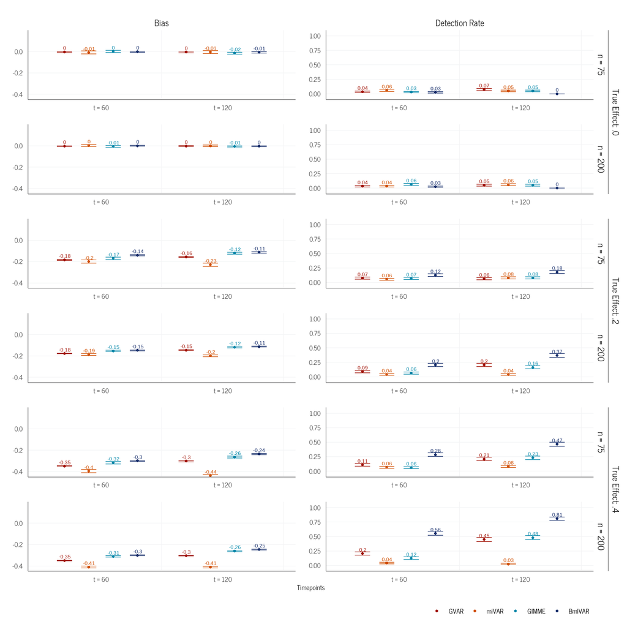

```r
power_bias_reg_strength_df <- sr_edit |>
  mutate(pm = str_replace(pm, "powertwoside", "power")) |>
  filter(!str_detect(pm, "poweroneside")) |>
  filter(str_detect(pm, "power") | str_detect(pm, "biasreg")) |>
    mutate(outcome = case_when(
    outcome == "outstrength" ~ "Temporal\nOutstrength",
    outcome == "strength" ~ "Contemporaneous\nStrength",
    outcome == "instrength" ~ "Temporal\nInstrength"
  )) |>
  filter(outcome == "Contemporaneous\nStrength") |>
  mutate(n_id = paste0("n = ", n_id)) |>
  mutate(n_id = factor(n_id, levels = c("n = 75", "n = 200"))) |>
  mutate(n_tp = paste0("t = ", n_tp)) |>
  mutate(n_tp = factor(n_tp, levels = c("t = 60", "t = 120"))) |>
  # split pm into two columns, take last number into new column
  separate_wider_delim(pm, delim = "reg", names = c("pm", "true_effect")) |>
  mutate(method = factor(method, levels = c("GVAR", "mlVAR", "GIMME", "BmlVAR"))) |>
  mutate(true_effect = paste0("True Effect: .", true_effect)) |>
  mutate(pm = case_when(
    str_detect(pm, "power") ~ "Detection Rate",
    str_detect(pm, "bias") ~ "Bias"
  ))

plot_power_bias_strength <- power_bias_reg_strength_df |>
  ggplot(aes(x = n_tp,
             y = mean,
             colour = method,
             fill = method,
             group = method))+
  geom_errorbar(aes(ymin = mean - 1 * mcse,
                      ymax = mean + 1 * mcse),
                  width = 0.5,
                  position = position_dodge(0.8),
                  show.legend = FALSE) +
    # add vertical
    geom_vline(colour = "#F3F4F5", xintercept = seq(1.5, 4, 1))+
    geom_point(position = position_dodge(0.8),
               size = 1.4) +
    # add mean as text above errorbar
    geom_text(aes(label = round(mean, 2)),
              position = position_dodge(0.8),
              vjust = -0.6,
              size = 5,
              show.legend = FALSE) +
    ggh4x::facet_nested(true_effect + n_id ~ pm,
                        axes = "all",
                        scales = "free_y",
                        independent = "y") +
    facetted_pos_scales(
      y = list(pm == "Bias" ~ scale_y_continuous(expand = c(0, 0), limits = c(-.45, .2)),
               pm == "Detection Rate" ~ scale_y_continuous(expand = c(0, 0), limits = c(-0.1, 1.1)))
    )+
    labs(
      title = "",
      x = "Timepoints",
      colour = "",
      fill = "",
      group = "",
      y = ""
    ) +
    scale_color_manual(values = meth_colors) +
    theme_centrality() +
    theme(legend.position = "bottom",
          ggh4x.facet.nestline = element_line(colour = "#6d6d6e"),
          axis.text = element_text(size = 18),
          # increase all legend element size
          legend.text = element_text(size = 18),
          legend.title = element_text(size = 18),
          legend.key.size = unit(1.5, "lines"),
          strip.text = ggplot2::element_text(size = 24),
          strip.text.x.top = ggplot2::element_text(size = 24)
          )

ggsave_rev("plot_power_bias_strength.pdf",
       plot_power_bias_strength, height = 16* 0.95, width = 16* 0.8,
       path = here::here("figures/"))
ggsave_rev("plot_power_bias_strength.svg",
       plot_power_bias_strength, height = 16* 0.95, width = 16* 0.8,
       path = here::here("scripts", "simulation_viz_figures"), device = "svg")

plot_power_bias_strength
```

## 9.4 RMSE and Bias of Regression

We create plot for different regression outcomes here:

```r
process_data <- function(data, summary) {
  df_clean <- data |>
    filter(str_detect(pm, summary)) |>
    mutate(outcome = case_when(
      outcome == "outstrength" ~ "Temporal\nOutstrength",
      outcome == "strength" ~ "Contemporaneous\nStrength",
      outcome == "instrength" ~ "Temporal\nInstrength"
    )) |>
    filter(outcome != "Contemporaneous\nStrength") |>
    mutate(
      n_id = factor(paste0("n = ", n_id), levels = c("n = 75", "n = 200")),
      n_tp = factor(paste0("t = ", n_tp), levels = c("t = 60", "t = 120"))
    ) |>
    separate_wider_delim(pm, delim = "reg", names = c("pm", "true_effect"))

    split(df_clean, df_clean$true_effect)
}

## Generic plotting function
create_regression_plot <- function(df,
                                   y_label) {
  ggplot(data = df,
         aes(
           x = n_tp,
           y = mean,
           colour = method,
           fill = method,
           group = method
         )) +
    # add horizontal dashed line at zero for bias
    geom_hline(yintercept = 0, linetype = 2, alpha = .4)+
    geom_errorbar(
      aes(ymin = mean - 1 * mcse, ymax = mean + 1 * mcse),
      width = .5,
      position = position_dodge(0.7),
      show.legend = FALSE
    ) +
    geom_point(position = position_dodge(0.7), size = 1.2) +
    ggh4x::facet_nested(n_id ~ outcome,
                        axes = "all",
                        remove_labels = "y") +
    scale_y_continuous(expand = c(0, 0), limits = c(-.45, .45)) +
    scale_color_manual(values = meth_colors) +
    theme_centrality() +
    theme(
      legend.position = "none",
      strip.text.x.top = ggplot2::element_text(size = rel(0.85)),
      ggh4x.facet.nestline = element_line(colour = "#6d6d6e"),
      axis.text = element_text(size = 18)
    ) +
    labs(
      title = "",
      x = "",
      colour = "",
      group = "",
      fill = "",
      y = y_label
    )
}

## Generate and save combined plots
generate_regression_plots <- function(data, summary, y_label, file_name) {
  processed_list <- process_data(data, summary)
  plot_list <- lapply(processed_list, create_regression_plot, y_label = y_label)
  combined_plot <- cowplot::plot_grid(
    plotlist = plot_list,
    ncol = 1,
    labels = c("True Effect: 0", "True Effect: 0.2", "True Effect: 0.4")
  )
  ggsave_rev(file_name, combined_plot, height = 16 * 0.95, width = 16 * 0.8,
         path = here::here("figures/"))
}


## RMSE Plot
generate_regression_plots(sr_edit, "rmsereg", "RMSE", "plot_reg_rmse_combined.pdf")

## Bias Plot
generate_regression_plots(sr_edit, "biasreg", "bias", "plot_reg_bias_combined.pdf")
```

Plot the RMSE:

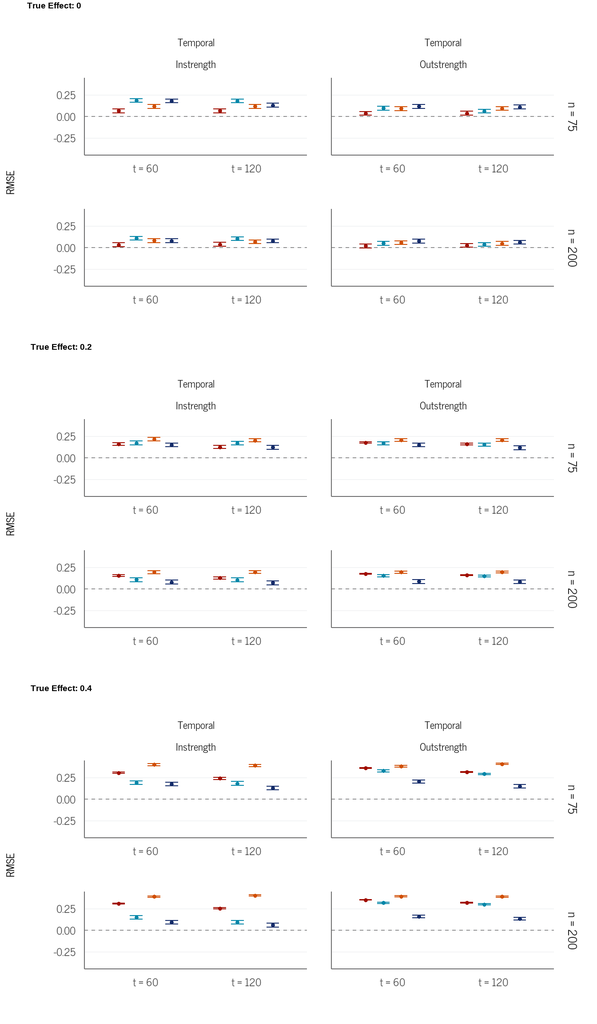

```r
processed_list <- process_data(sr_edit, "rmsereg")
plot_power_rmse_strength <- lapply(processed_list, create_regression_plot, y_label = "RMSE")
combined_plot <- cowplot::plot_grid(
  plotlist = plot_power_rmse_strength,
  ncol = 1,
  labels = c("True Effect: 0", "True Effect: 0.2", "True Effect: 0.4")
)
combined_plot
```

Plot the bias:

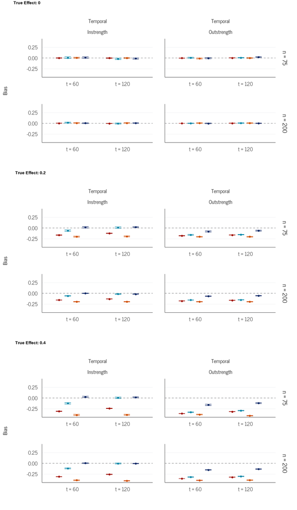

```r
processed_list <- process_data(sr_edit, "biasreg")
plot_power_bias_strength <- lapply(processed_list, create_regression_plot, y_label = "Bias")
combined_plot <- cowplot::plot_grid(
  plotlist = plot_power_bias_strength,
  ncol = 1,
  labels = c("True Effect: 0", "True Effect: 0.2", "True Effect: 0.4")
)

combined_plot
```

## 9.5 Variability of Point Estimates

Here, we investigate the variability of point estimates in specific simulation conditions, for which we need the raw results - this part is therefore not reproducible. Again, this code is commented out not to clash with our make execution. Simply uncomment and run to reproduce manually.

```r
# if(isTRUE(use_rev)){
#   r3 <- readRDS(here::here("output/rev1_fixed_sigma/sim_full_rev1_cond23_fixed_sigma.rds-results_pc04669/results-row-2.rds"))
# } else {
#   r3 <- readRDS("~/centrality-uncertainty/sim_full.rds-results_pc04798/results-row-3.rds")
# }
```

For easier interpretation, we plot the raw estimates instead of the bias.

```r
# # extract regression slope for a given method and repetition
# extract_coef <- function(res_list, method) {
#    map_dfr(res_list, function(x) {
#      if (!is.null(x[[method]])) {
#        if (method == "bmlvar") {
#          tmp <- x[[method]]$reg_bmlvar$regression_slope$median
#          tibble(
#            `0.0` = tmp[4],
#            `0.2` = tmp[5],
#            `0.4` = tmp[6],
#            method = "BmlVAR"
#          )
#        } else {
#          tibble(
#            `0.0` = tryCatch(summary(x[[method]]$reg_outstrength[[1]])$coefficients[2], error = function(e) NA),
#            `0.2` = tryCatch(summary(x[[method]]$reg_outstrength[[2]])$coefficients[2], error = function(e) NA),
#            `0.4` = tryCatch(summary(x[[method]]$reg_outstrength[[3]])$coefficients[2], error = function(e) NA),
#            method = method
#          )
#        }
#      } else {
#        NULL
#      }
#    })
#  }
#
#
# methods <- c("gvar", "gimme", "mlvar", "bmlvar")
# df_all <- map_dfr(methods, ~ extract_coef(r3$results, .x))
#
#
# df_all <- df_all |>
#    mutate(method = recode(method,
#                           "mlvar" = "mlVAR",
#                           "gimme" = "GIMME",
#                           "gvar" = "GVAR")) |>
#    mutate(method = factor(method, levels = c("GVAR", "GIMME", "mlVAR", "BmlVAR")))
#
# #  Plot
# est_variability_plot <- df_all |>
#    pivot_longer(cols = c("0.0", "0.2", "0.4"), names_to = "reg_coef") |>
#    mutate(
#      reg_coef = as.factor(reg_coef),
#       method = factor(method, levels = names(meth_colors))
#    ) |>
#    ggplot(aes(x = reg_coef, y = value, fill = method, color = method)) +
#    geom_point(position = position_jitterdodge(jitter.width = 0.35,
#                                                dodge.width = 0.8,
#                                                jitter.height = 0),
#               size = 1.5,
#               alpha = 0.4) +
#    geom_boxplot(position = position_dodge(width = 0.8),
#                 outlier.shape = NA, alpha = 0.7) +
#    labs(x = "True Regression Slope",
#         y = "Estimated Regression Slope",
#         color = "",
#         fill = "") +
#    theme_centrality() +
#    theme(text = element_text(size = 21)) +
#    scale_fill_manual(values = meth_colors) +
#    scale_color_manual(values = meth_colors) +
#    scale_y_continuous(breaks = round(seq(-0.6, 1, by = .2), 1))+
#    geom_vline(colour = "darkgrey", xintercept = seq(1.5, 3, 1))
#
# ggsave_rev("est_variability_plot.pdf", plot = est_variability_plot,
#         height = 6, width = 9,
#         path = here::here("figures/"), device = "pdf")
#
# # save plot as rds
# saveRDS(est_variability_plot, here::here("figures", "rev1", "est_variability_plot.rds"))
```

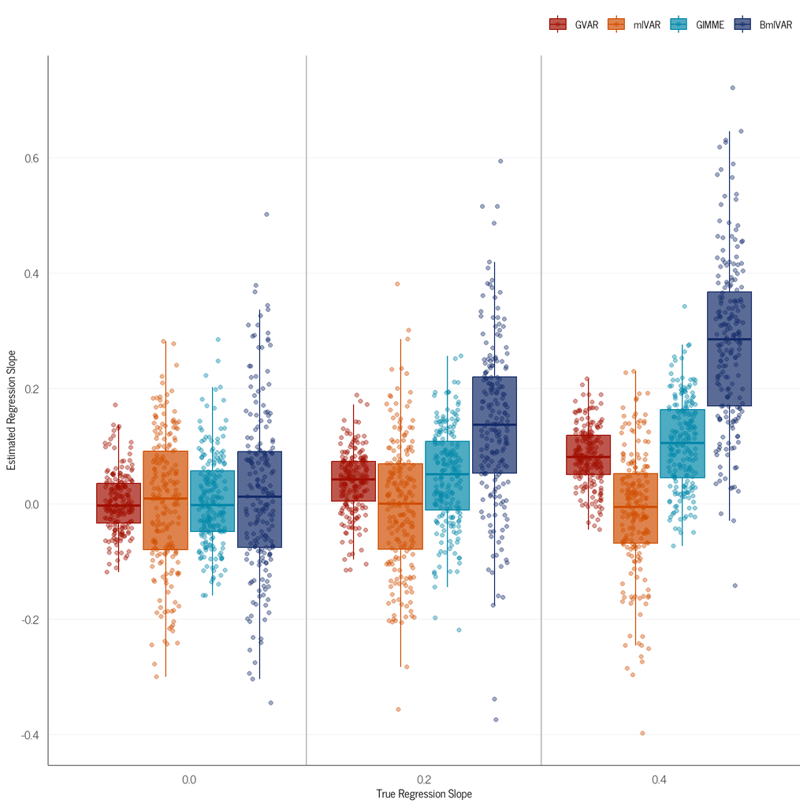

# 10 MCMC Diagnostics

We can now look at the Bayesian models in more detail and check if the Rhats are satisfactory, as well as if there were any divergent transitions.

First, look at Rhats:

```r
sim_results |>
  select(bmlvar_diagnostics.rhat_bmlvar_mean) |>
  rename("Mean Rhat" = bmlvar_diagnostics.rhat_bmlvar_mean) |>
  knitr::kable()
```

| Mean Rhat |
| --- |
| 1.0006488 |
| 0.9996415 |
| 0.9999851 |
| 0.9998444 |

Second, we tabulate divergent transitions:

```r
sim_results |>
  select(contains("divtrans")) |>
  rename_with(~ str_remove(., "bmlvar_diagnostics."), everything()) |>
  knitr::kable(col.names = c("Mean Number of DivTrans",
                            "Sum of DivTrans",
                            "Models with Divtrans"))
```

| Mean Number of DivTrans | Sum of DivTrans | Models with Divtrans |
| --- | --- | --- |
| 8.77 | 1754 | 98 |
| 0.14 | 28 | 3 |
| 1.58 | 316 | 23 |
| 0.00 | 0 | 0 |

# 11 Session Info

Please note that the visualizations were redone in an updated R version, but the computations of the simulation were run in a previous R version as indicated in the Dockerfile.

**R version 4.5.2 (2025-10-31 ucrt)**

**Platform:** x86_64-w64-mingw32/x64

**locale:** *LC_COLLATE=German_Germany.utf8*, *LC_CTYPE=German_Germany.utf8*, *LC_MONETARY=German_Germany.utf8*, *LC_NUMERIC=C* and *LC_TIME=German_Germany.utf8*

**attached base packages:** *stats*, *graphics*, *grDevices*, *utils*, *datasets*, *methods* and *base*

**other attached packages:** *lm.beta(v.1.7-2)*, *here(v.1.0.1)*, *MetBrewer(v.0.2.0)*, *pander(v.0.6.6)*, *ggh4x(v.0.3.0)*, *janitor(v.2.2.1)*, *ggokabeito(v.0.1.0)*, *showtext(v.0.9-7)*, *showtextdb(v.3.0)*, *sysfonts(v.0.8.9)*, *cowplot(v.1.1.3)*, *SimDesign(v.2.19.2)*, *lubridate(v.1.9.4)*, *forcats(v.1.0.0)*, *stringr(v.1.5.1)*, *dplyr(v.1.1.4)*, *purrr(v.1.0.4)*, *readr(v.2.1.5)*, *tidyr(v.1.3.1)*, *tibble(v.3.2.1)*, *ggplot2(v.3.5.2)* and *tidyverse(v.2.0.0)*

**loaded via a namespace (and not attached):** *gtable(v.0.3.6)*, *xfun(v.0.52)*, *htmlwidgets(v.1.6.4)*, *tzdb(v.0.5.0)*, *vctrs(v.0.6.5)*, *tools(v.4.5.2)*, *generics(v.0.1.3)*, *curl(v.6.2.2)*, *parallel(v.4.5.2)*, *pkgconfig(v.2.0.3)*, *R.oo(v.1.27.0)*, *RColorBrewer(v.1.1-3)*, *lifecycle(v.1.0.4)*, *compiler(v.4.5.2)*, *farver(v.2.1.2)*, *textshaping(v.1.0.0)*, *brio(v.1.1.5)*, *codetools(v.0.2-20)*, *snakecase(v.0.11.1)*, *htmltools(v.0.5.8.1)*, *yaml(v.2.3.10)*, *pillar(v.1.10.2)*, *R.utils(v.2.13.0)*, *sessioninfo(v.1.2.3)*, *parallelly(v.1.43.0)*, *tidyselect(v.1.2.1)*, *digest(v.0.6.37)*, *stringi(v.1.8.7)*, *future(v.1.40.0)*, *listenv(v.0.9.1)*, *labeling(v.0.4.3)*, *rprojroot(v.2.0.4)*, *fastmap(v.1.2.0)*, *grid(v.4.5.2)*, *cli(v.3.6.5)*, *beepr(v.2.0)*, *magrittr(v.2.0.3)*, *future.apply(v.1.11.3)*, *withr(v.3.0.2)*, *scales(v.1.4.0)*, *timechange(v.0.3.0)*, *rmarkdown(v.2.29)*, *globals(v.0.17.0)*, *audio(v.0.1-11)*, *progressr(v.0.15.1)*, *ragg(v.1.4.0)*, *R.methodsS3(v.1.8.2)*, *hms(v.1.1.3)*, *pbapply(v.1.7-2)*, *evaluate(v.1.0.3)*, *knitr(v.1.50)*, *testthat(v.3.2.3)*, *rlang(v.1.1.6)*, *Rcpp(v.1.0.14)*, *xtable(v.1.8-4)*, *glue(v.1.8.0)*, *svglite(v.2.2.2)*, *rstudioapi(v.0.17.1)*, *jsonlite(v.2.0.0)*, *R6(v.2.6.1)* and *systemfonts(v.1.3.2)*